# CEU DV3: Example homework solutions

Gergely Daroczi

January 24, 2024

## 0. Load the `nycflights13` package and check what datasets are bundled.

| Package | LibPath | Item | Title |
| --- | --- | --- | --- |
| nycflights13 | /usr/lib/R/library | airlines | Airline names. |
| nycflights13 | /usr/lib/R/library | airports | Airport metadata |
| nycflights13 | /usr/lib/R/library | flights | Flights data |
| nycflights13 | /usr/lib/R/library | planes | Plane metadata. |
| nycflights13 | /usr/lib/R/library | weather | Hourly weather data |

## 1. Visualize the distribution of arrival delays per origin airport!

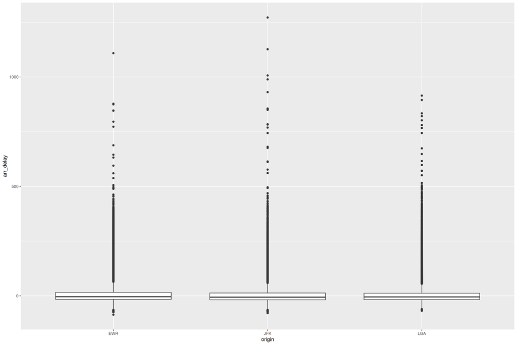

## 2. Visualize the distribution of arrival delays per destination airport! Note that the x axis labels need to be rotated, and spend some time cleaning up the axis and plot titles! Might need to tweak `fig.height` and `fig.width` params of the code chunk in Rmd!

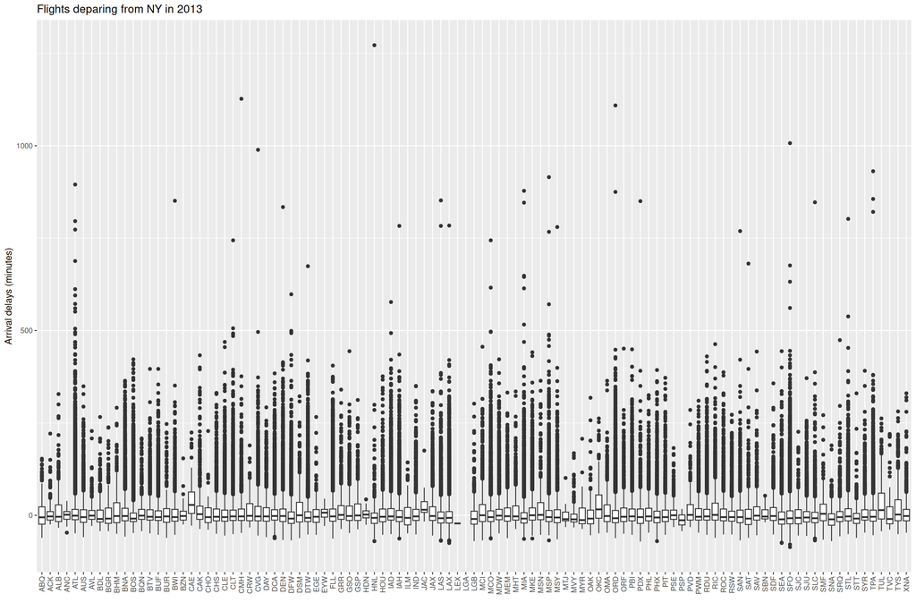

## 3. Compute and visualize the average arrival delay per destination! Make sure to handle `NA`s and order the barplot by the average delay.

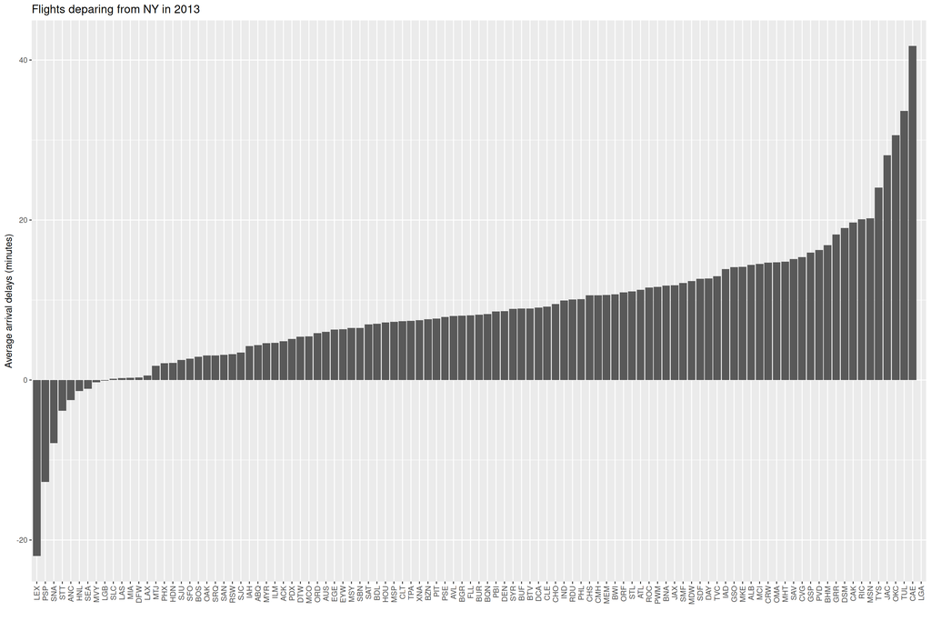

## 4. Redo the above plot by showing the actual name of the destination airport instead of it’s FAA id!

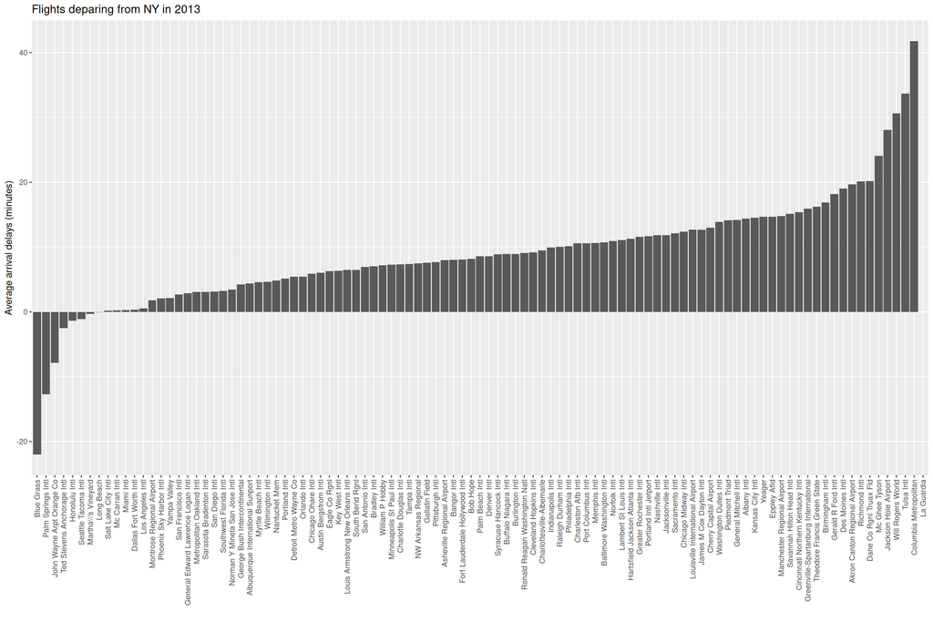

## 5. Color the bars by the timezone of the airport! Make sure to render the legend on the top, using a single line.

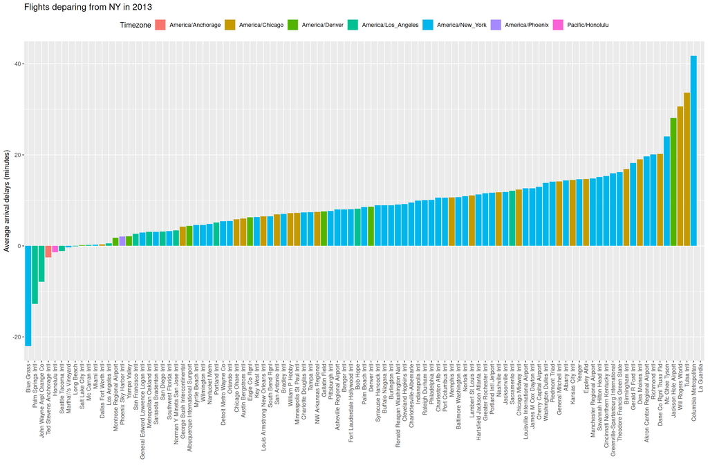

## 6. Geocode the destination airports, then visualize those on a worldmap with the point sizes relative to the number of flights to there from NY!

```
## Passing 105 addresses to the Nominatim single address geocoder
```

```
## Query completed in: 105.6 seconds
```

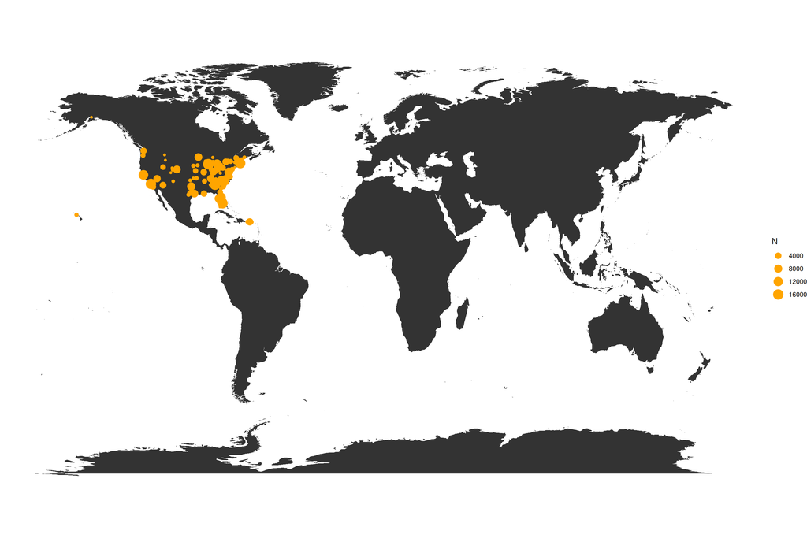

## 7. Compute the average departure and arrival delays, also the average air time and distance per destination, then pass the scaled dataframe through MDS to visualize the similarities/dissimilarities of the destination airports!

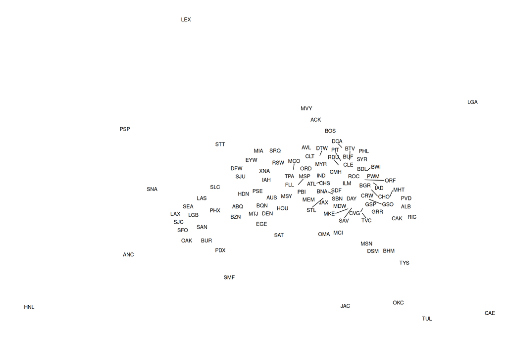